# Assignment 3

## only two interact variable

```r
mod5 <- lm(Price ~  Type + Distance + Bathroom + Rooms * Bedroom2, data=Houses_true)
summary(mod5)
```

```
##
## Call:
## lm(formula = Price ~ Type + Distance + Bathroom + Rooms * Bedroom2,
##     data = Houses_true)
##
## Residuals:
##      Min       1Q   Median       3Q      Max
## -1869333  -290662   -70474   198445  3976641
##
## Coefficients:
##                 Estimate Std. Error t value Pr(>|t|)
## (Intercept)     540676.3    31089.7  17.391  < 2e-16 ***
## Typet          -300801.6    12987.2 -23.161  < 2e-16 ***
## Typeu          -388875.8    11333.6 -34.312  < 2e-16 ***
## Distance        -40246.4      529.6 -75.995  < 2e-16 ***
## Bathroom        260123.0     6222.4  41.805  < 2e-16 ***
## Rooms           184165.0    16860.6  10.923  < 2e-16 ***
## Bedroom2         74793.2    17062.5   4.383 1.17e-05 ***
## Rooms:Bedroom2  -11303.2     2656.6  -4.255 2.10e-05 ***
## ---
## Signif. codes:  0 '***' 0.001 '**' 0.01 '*' 0.05 '.' 0.1 ' ' 1
##
## Residual standard error: 476500 on 20699 degrees of freedom
## Multiple R-squared:  0.4346, Adjusted R-squared:  0.4344
## F-statistic:  2273 on 7 and 20699 DF,  p-value: < 2.2e-16
```

adjusted R^2=0.4344

## three interact variable

```r
mod6 <- lm(Price ~  Type + Distance + Rooms * Bathroom * Bedroom2, data=Houses_true)
summary(mod6)
```

```
##
## Call:
## lm(formula = Price ~ Type + Distance + Rooms * Bathroom * Bedroom2,
##     data = Houses_true)
##
## Residuals:
##      Min       1Q   Median       3Q      Max
## -2245611  -288347   -74621   196512  3920402
##
## Coefficients:
##                         Estimate Std. Error t value Pr(>|t|)
## (Intercept)              1092663      63989  17.076  < 2e-16 ***
## Typet                    -276533      12975 -21.313  < 2e-16 ***
## Typeu                    -392717      11299 -34.756  < 2e-16 ***
## Distance                  -40107        526 -76.253  < 2e-16 ***
## Rooms                      61353      37019   1.657 0.097462 .
## Bathroom                 -377767      46674  -8.094 6.10e-16 ***
## Bedroom2                   61752      36628   1.686 0.091830 .
## Rooms:Bathroom            154426      20316   7.601 3.06e-14 ***
## Rooms:Bedroom2            -20463       5719  -3.578 0.000347 ***
## Bathroom:Bedroom2          99382      19846   5.008 5.55e-07 ***
## Rooms:Bathroom:Bedroom2   -19395       2802  -6.922 4.58e-12 ***
## ---
## Signif. codes:  0 '***' 0.001 '**' 0.01 '*' 0.05 '.' 0.1 ' ' 1
##
## Residual standard error: 473100 on 20696 degrees of freedom
## Multiple R-squared:  0.4426, Adjusted R-squared:  0.4423
## F-statistic:  1643 on 10 and 20696 DF,  p-value: < 2.2e-16
```

adjusted R^2=0.4423

## four interact variable

```r
mod7 <- lm(Price ~  Type + Distance * Rooms * Bathroom * Bedroom2 , data=Houses_true)
summary(mod7)
```

```
##
## Call:
## lm(formula = Price ~ Type + Distance * Rooms * Bathroom * Bedroom2,
##     data = Houses_true)
##
## Residuals:
##      Min       1Q   Median       3Q      Max
## -2486513  -276621   -59819   187578  3785237
##
## Coefficients:
##                                   Estimate Std. Error t value Pr(>|t|)
## (Intercept)                      1079253.9   101993.8  10.582  < 2e-16 ***
## Typet                            -287465.3    12672.4 -22.684  < 2e-16 ***
## Typeu                            -382725.1    11038.7 -34.671  < 2e-16 ***
## Distance                            2725.6     9013.3   0.302 0.762351
## Rooms                             -70520.0    89515.9  -0.788 0.430827
## Bathroom                         -564183.6    81543.1  -6.919 4.69e-12 ***
## Bedroom2                          -35999.6    89455.1  -0.402 0.687370
## Distance:Rooms                      1312.7     8869.2   0.148 0.882343
## Distance:Bathroom                   6272.7     6545.5   0.958 0.337912
## Rooms:Bathroom                    290551.8    52297.2   5.556 2.80e-08 ***
## Distance:Bedroom2                  -4502.7     8809.5  -0.511 0.609270
## Rooms:Bedroom2                     27026.6     9748.0   2.773 0.005567 **
## Bathroom:Bedroom2                 135535.2    52109.5   2.601 0.009303 **
## Distance:Rooms:Bathroom           -10925.4     5012.4  -2.180 0.029294 *
## Distance:Rooms:Bedroom2             -978.2      758.0  -1.291 0.196883
## Distance:Bathroom:Bedroom2          1390.0     4925.3   0.282 0.777778
## Rooms:Bathroom:Bedroom2           -39641.7     4709.7  -8.417  < 2e-16 ***
## Distance:Rooms:Bathroom:Bedroom2    1065.0      289.7   3.676 0.000237 ***
## ---
## Signif. codes:  0 '***' 0.001 '**' 0.01 '*' 0.05 '.' 0.1 ' ' 1
##
## Residual standard error: 460900 on 20689 degrees of freedom
## Multiple R-squared:  0.4711, Adjusted R-squared:  0.4707
## F-statistic:  1084 on 17 and 20689 DF,  p-value: < 2.2e-16
```

adjusted R^2=0.4707

## goodness-of-fit

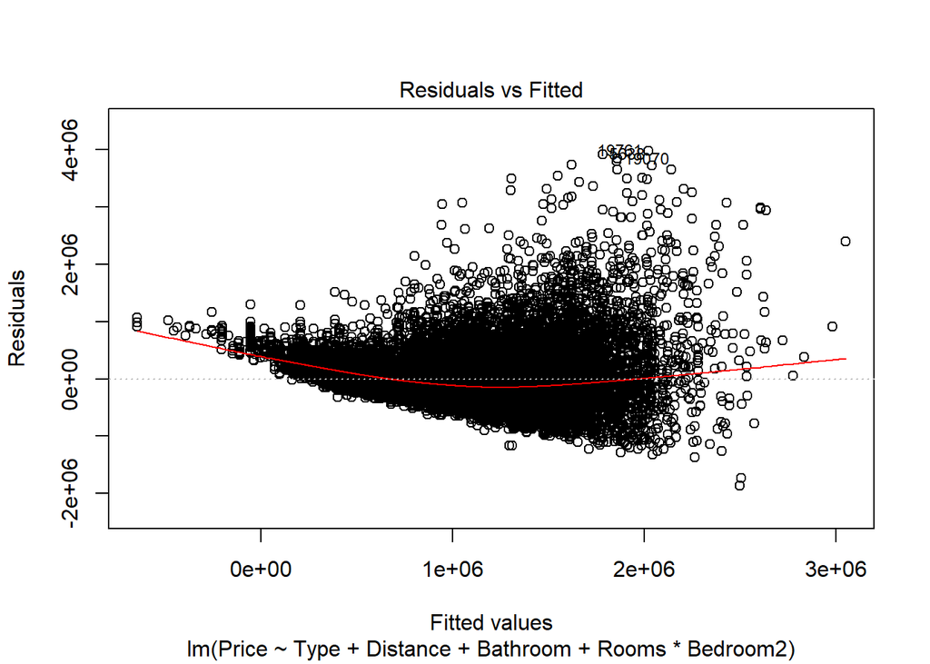

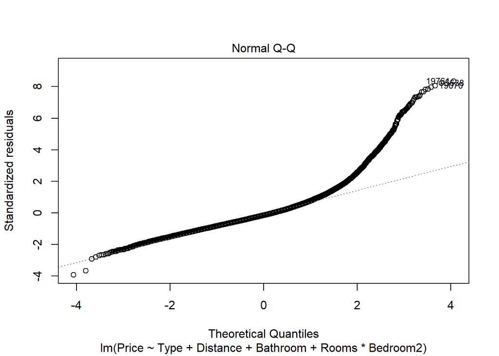

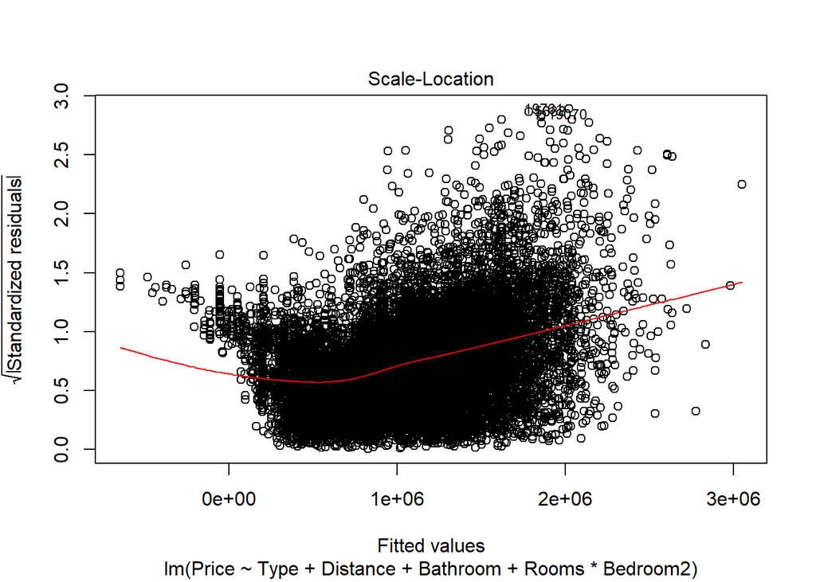

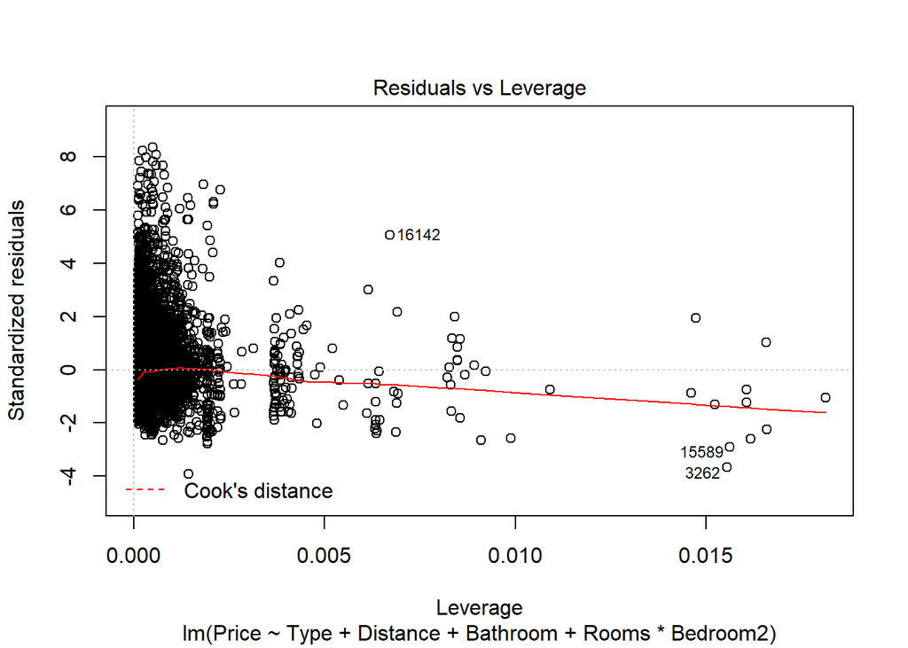

```r
plot(mod5)
```

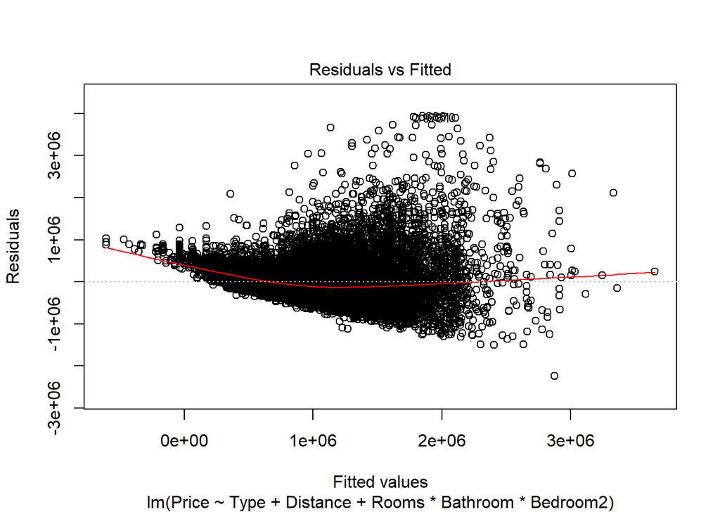

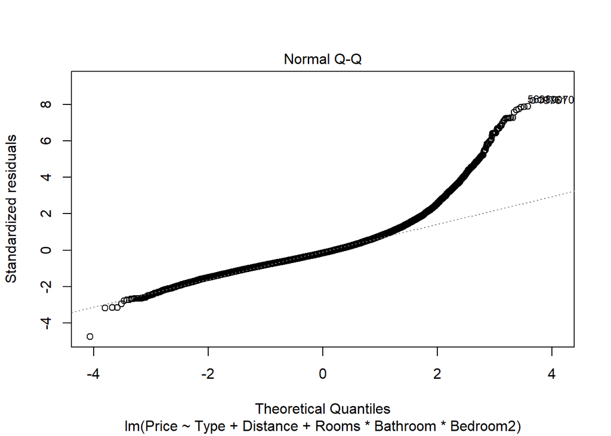

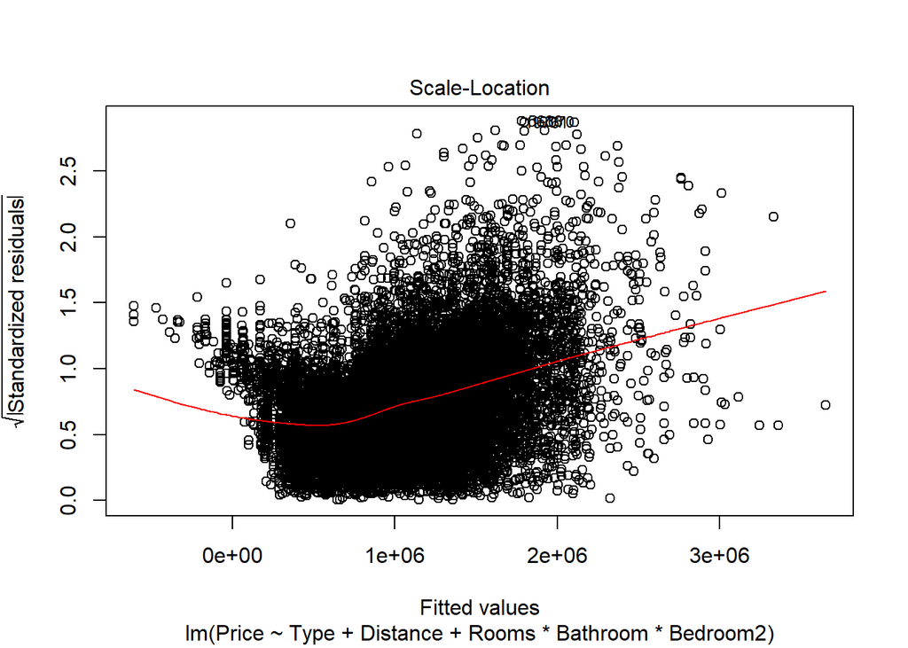

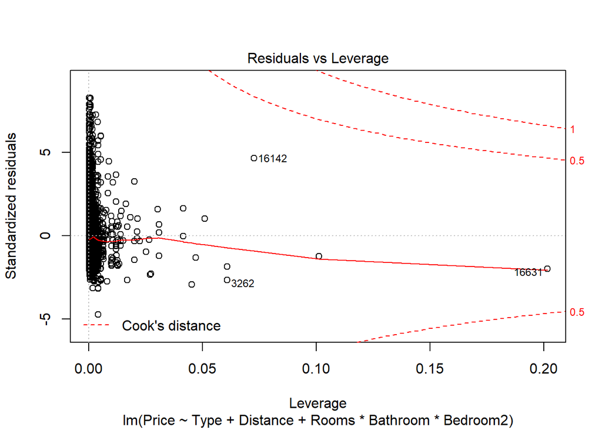

```r
plot(mod6)
```

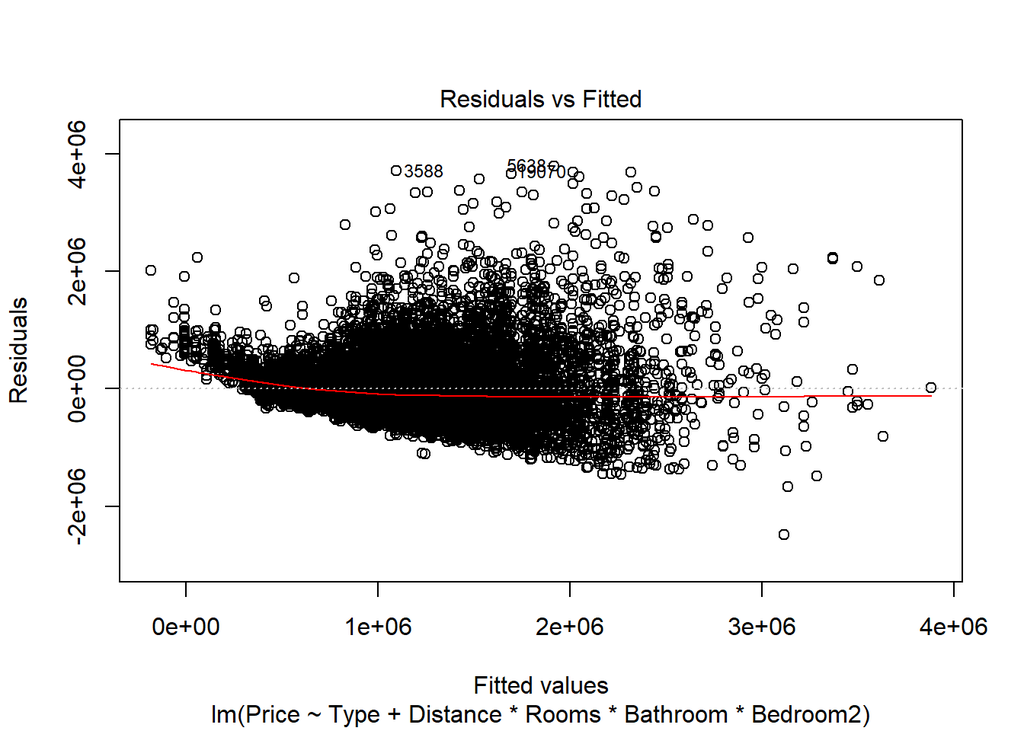

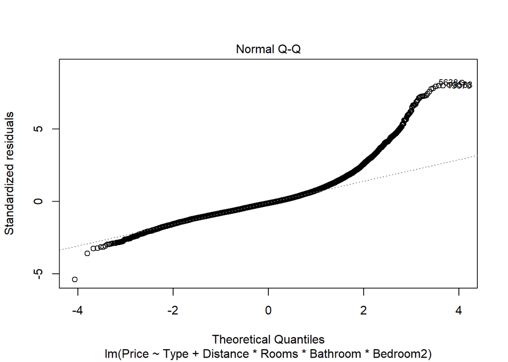

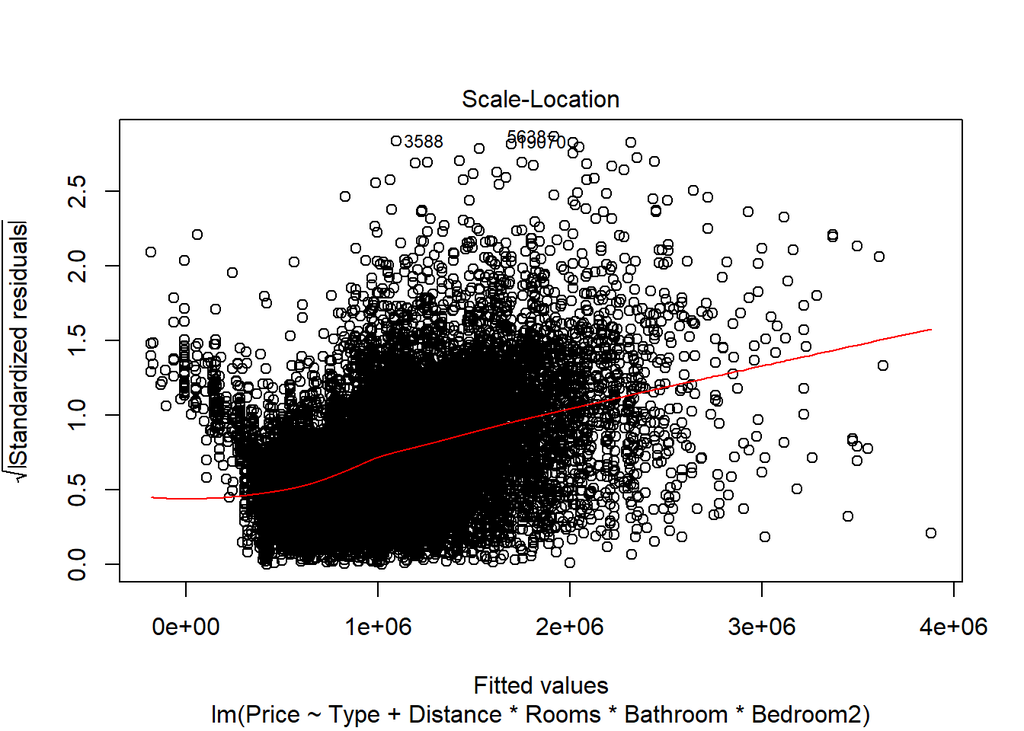

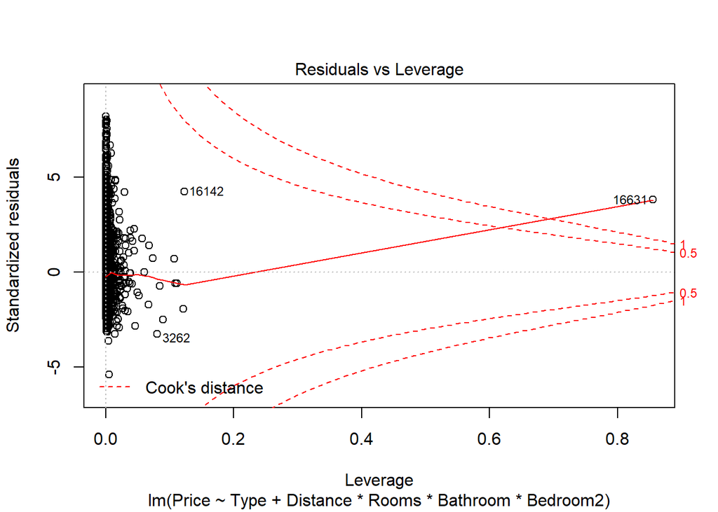

```r
plot(mod7)
```

#we can see there are clearly a v=curve pattern in the residual plot, we will try the log equation

```r
mod8 <- lm(log(Price) ~  Type + Distance + Bathroom + Rooms * Bedroom2, data=Houses_true)
mod9 <- lm(log(Price) ~  Type + Distance + Rooms * Bathroom * Bedroom2, data=Houses_true)
mod10 <- lm(log(Price) ~  Type + Distance * Rooms * Bathroom * Bedroom2 , data=Houses_true)
```

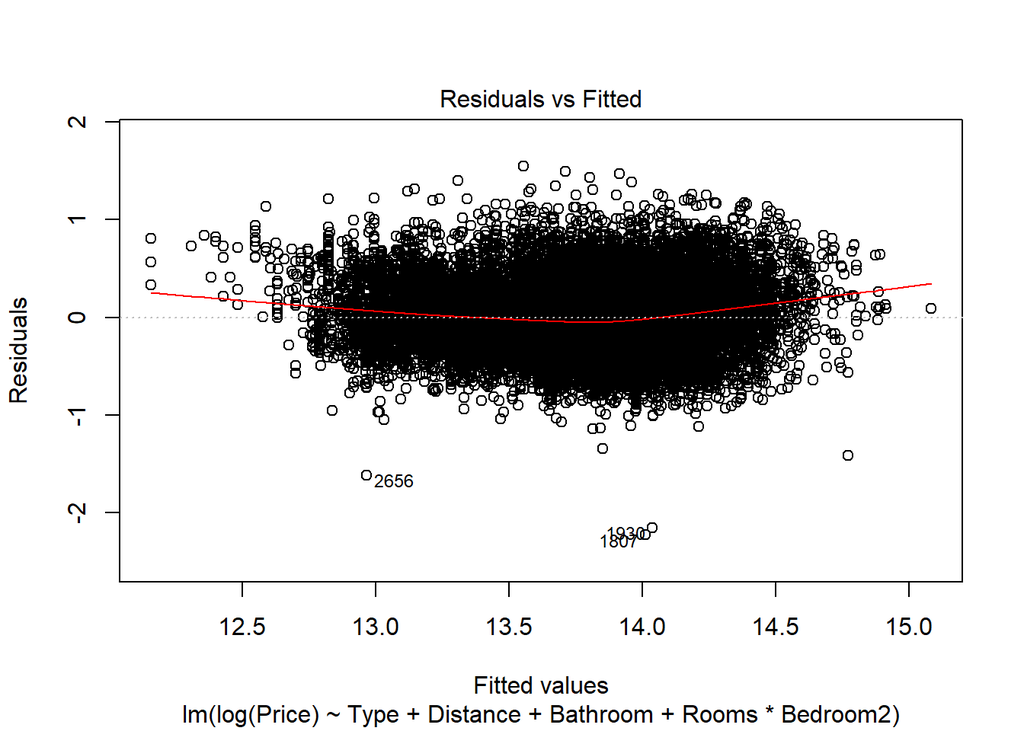

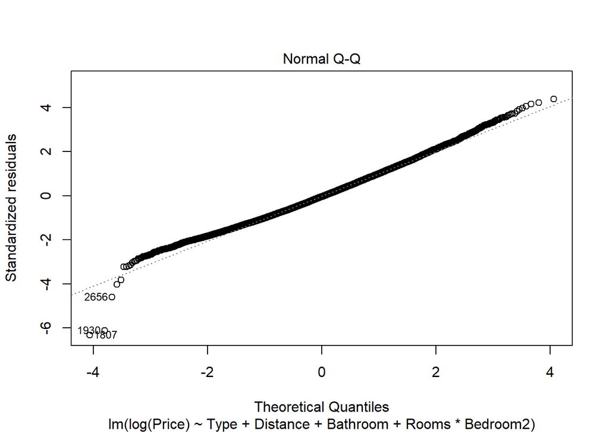

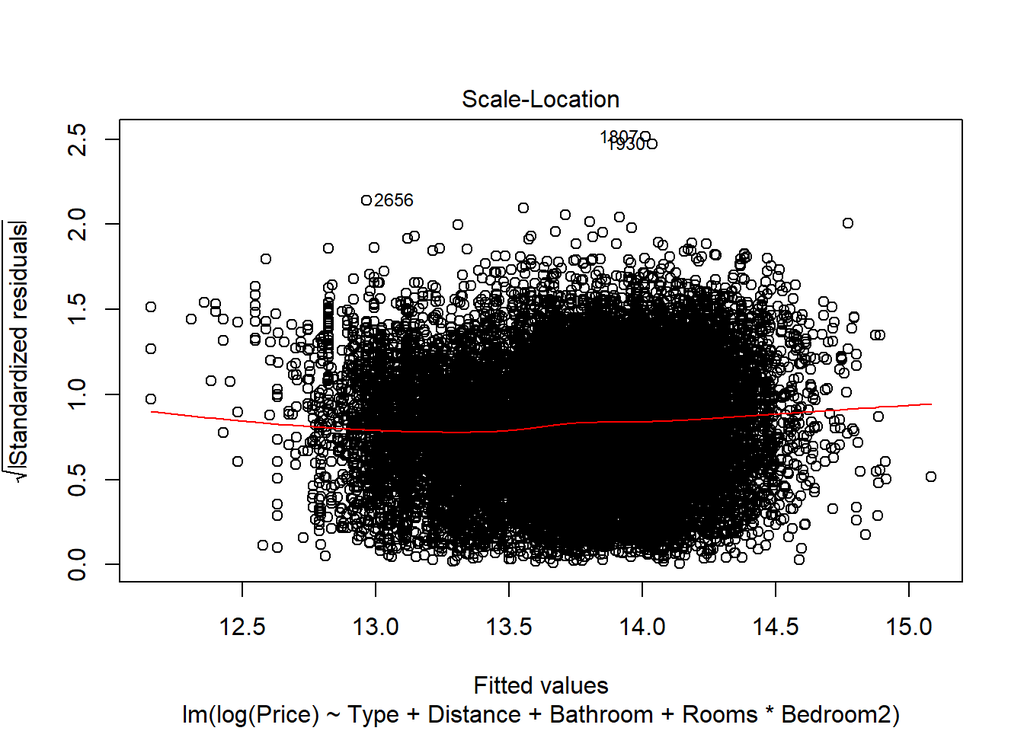

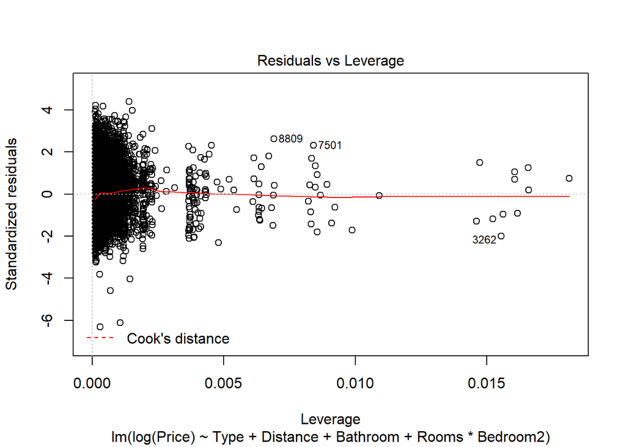

```r
plot(mod8)
```

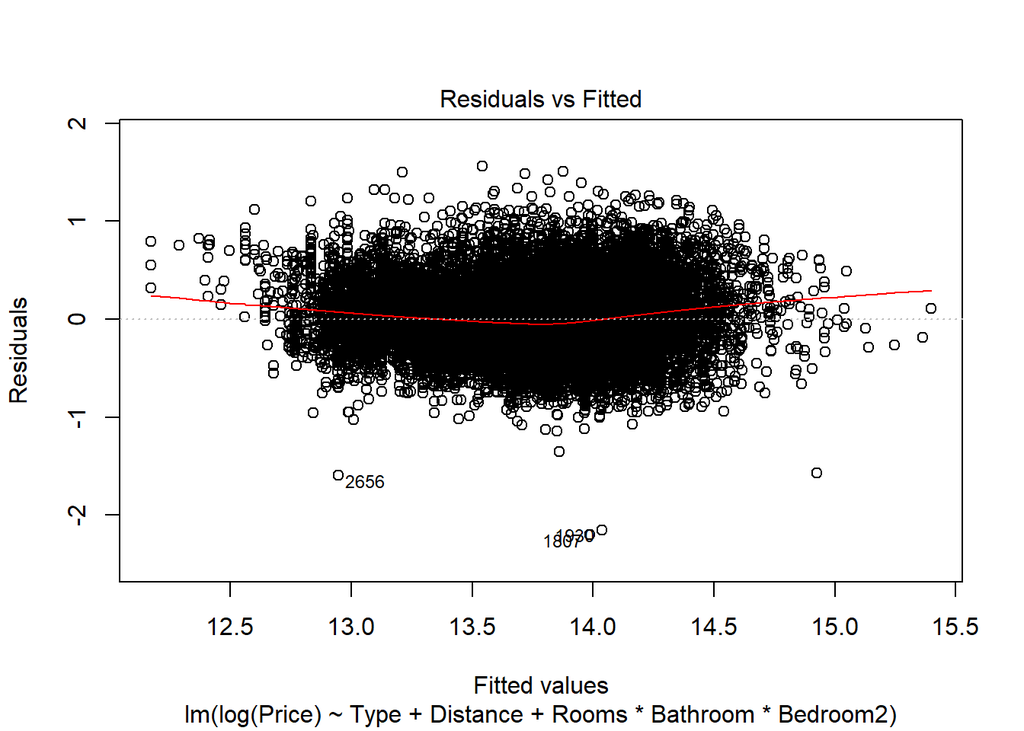

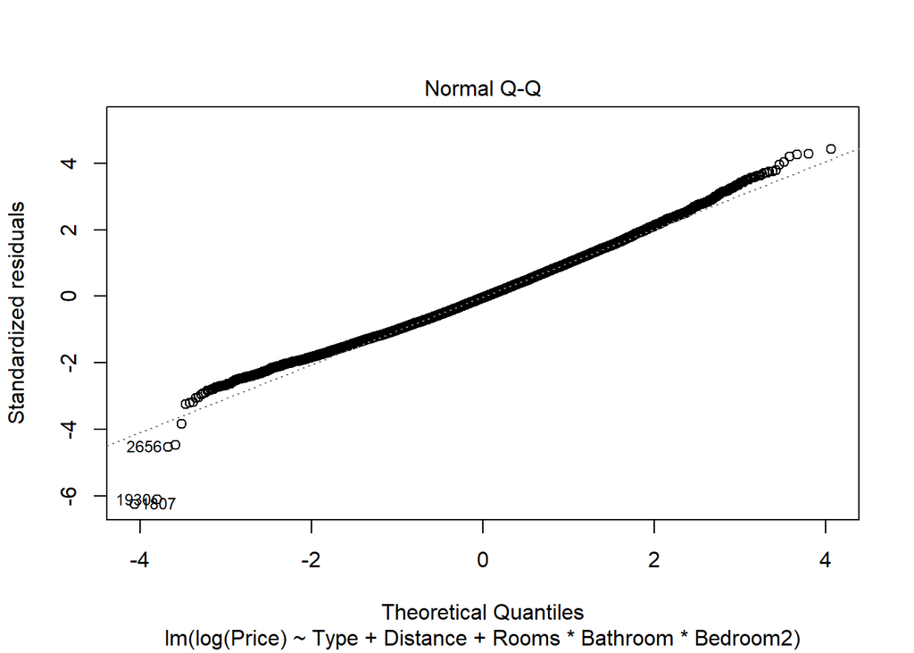

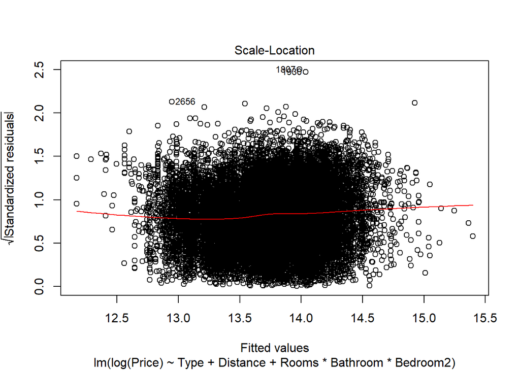

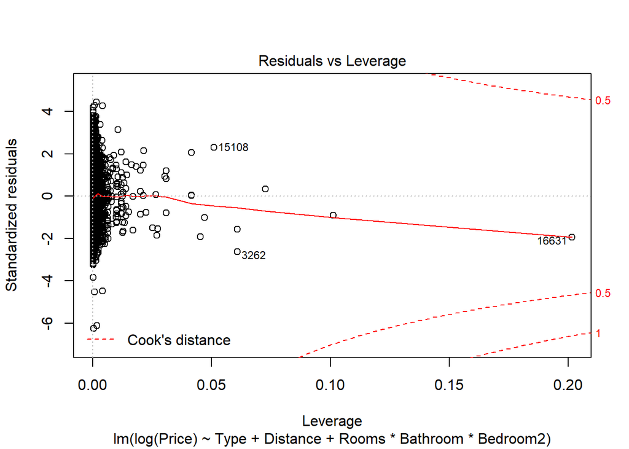

```r
plot(mod9)
```

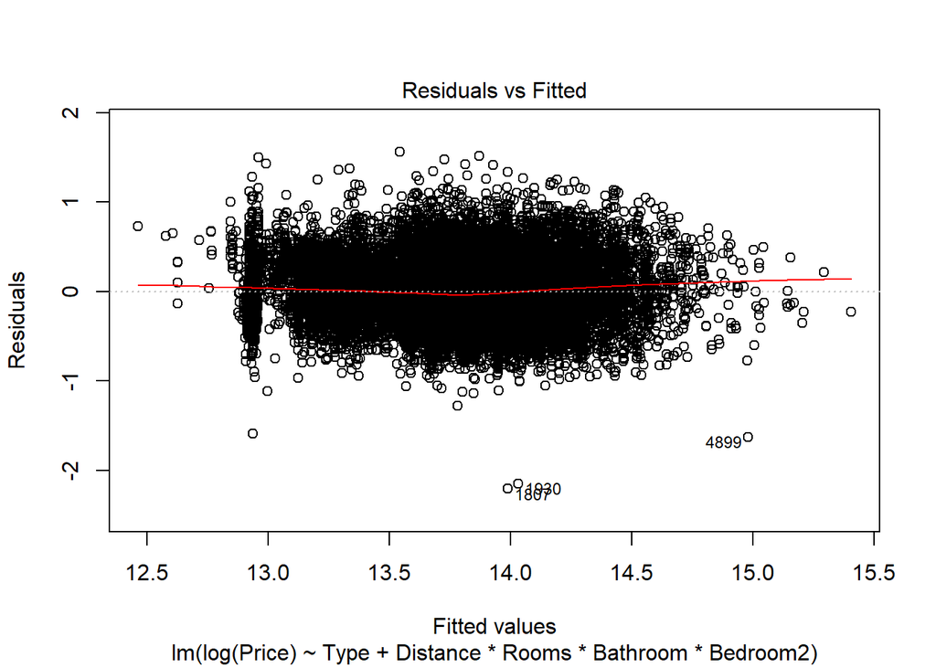

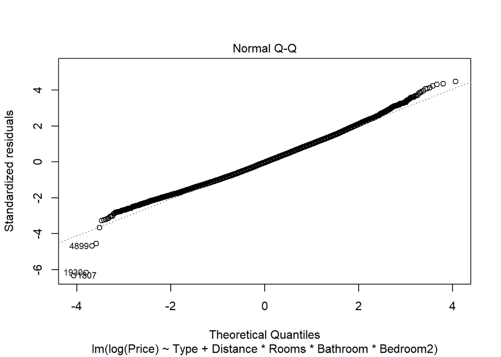

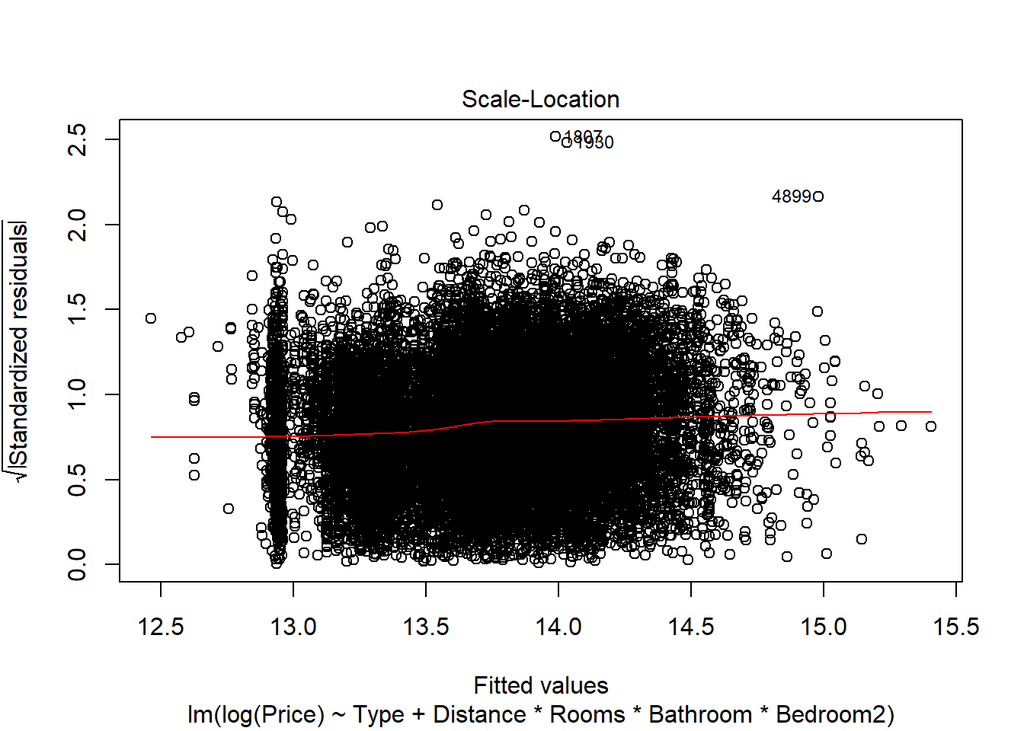

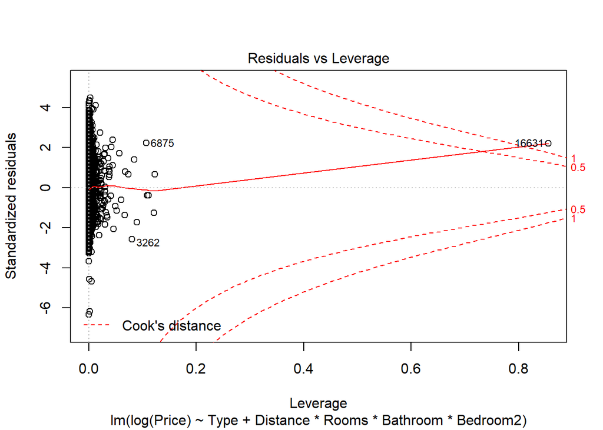

```r
plot(mod10)
```

#there still slightly have some patterns and outliers, but the residual follow the normal distribution. log funtion residuals are much better than linear equation.

```r
summary(mod8)
```

```
##
## Call:
## lm(formula = log(Price) ~ Type + Distance + Bathroom + Rooms *
##     Bedroom2, data = Houses_true)
##
## Residuals:
##      Min       1Q   Median       3Q      Max
## -2.22921 -0.25123 -0.01375  0.23313  1.54864
##
## Coefficients:
##                  Estimate Std. Error t value Pr(>|t|)
## (Intercept)    13.0543615  0.0229986  567.62   <2e-16 ***
## Typet          -0.2245225  0.0096073  -23.37   <2e-16 ***
## Typeu          -0.4304544  0.0083840  -51.34   <2e-16 ***
## Distance       -0.0356717  0.0003918  -91.05   <2e-16 ***
## Bathroom        0.1715775  0.0046030   37.27   <2e-16 ***
## Rooms           0.2631165  0.0124726   21.10   <2e-16 ***
## Bedroom2        0.1779680  0.0126220   14.10   <2e-16 ***
## Rooms:Bedroom2 -0.0412900  0.0019652  -21.01   <2e-16 ***
## ---
## Signif. codes:  0 '***' 0.001 '**' 0.01 '*' 0.05 '.' 0.1 ' ' 1
##
## Residual standard error: 0.3525 on 20699 degrees of freedom
## Multiple R-squared:   0.53,  Adjusted R-squared:  0.5298
## F-statistic:  3334 on 7 and 20699 DF,  p-value: < 2.2e-16
```

```r
summary(mod9)
```

```
##
## Call:
## lm(formula = log(Price) ~ Type + Distance + Rooms * Bathroom *
##     Bedroom2, data = Houses_true)
##
## Residuals:
##      Min       1Q   Median       3Q      Max
## -2.20220 -0.25121 -0.01485  0.23241  1.56134
##
## Coefficients:
##                           Estimate Std. Error t value Pr(>|t|)
## (Intercept)             13.0508302  0.0475905 274.232  < 2e-16 ***
## Typet                   -0.2177438  0.0096497 -22.565  < 2e-16 ***
## Typeu                   -0.4280043  0.0084036 -50.931  < 2e-16 ***
## Distance                -0.0356309  0.0003912 -91.085  < 2e-16 ***
## Rooms                    0.2987780  0.0275316  10.852  < 2e-16 ***
## Bathroom                 0.0820928  0.0347123   2.365   0.0180 *
## Bedroom2                 0.2164133  0.0272413   7.944 2.05e-15 ***
## Rooms:Bathroom           0.0057403  0.0151092   0.380   0.7040
## Rooms:Bedroom2          -0.0624555  0.0042535 -14.683  < 2e-16 ***
## Bathroom:Bedroom2        0.0069290  0.0147596   0.469   0.6388
## Rooms:Bathroom:Bedroom2  0.0035742  0.0020839   1.715   0.0863 .
## ---
## Signif. codes:  0 '***' 0.001 '**' 0.01 '*' 0.05 '.' 0.1 ' ' 1
##
## Residual standard error: 0.3519 on 20696 degrees of freedom
## Multiple R-squared:  0.5316, Adjusted R-squared:  0.5314
## F-statistic:  2349 on 10 and 20696 DF,  p-value: < 2.2e-16
```

```r
summary(mod10)
```

```
##
## Call:
## lm(formula = log(Price) ~ Type + Distance * Rooms * Bathroom *
##     Bedroom2, data = Houses_true)
##
## Residuals:
##      Min       1Q   Median       3Q      Max
## -2.20690 -0.24816 -0.01127  0.23174  1.56022
##
## Coefficients:
##                                    Estimate Std. Error t value Pr(>|t|)
## (Intercept)                      12.6368821  0.0770878 163.928  < 2e-16
## Typet                            -0.2270894  0.0095779 -23.710  < 2e-16
## Typeu                            -0.4265467  0.0083431 -51.125  < 2e-16
## Distance                          0.0369989  0.0068123   5.431 5.66e-08
## Rooms                             0.3641369  0.0676569   5.382 7.44e-08
## Bathroom                          0.1791409  0.0616310   2.907  0.00366
## Bedroom2                          0.2687733  0.0676110   3.975 7.05e-05
## Distance:Rooms                   -0.0157795  0.0067034  -2.354  0.01858
## Distance:Bathroom                -0.0195829  0.0049471  -3.958 7.57e-05
## Rooms:Bathroom                    0.0095003  0.0395267   0.240  0.81006
## Distance:Bedroom2                -0.0147741  0.0066583  -2.219  0.02650
## Rooms:Bedroom2                   -0.0663684  0.0073676  -9.008  < 2e-16
## Bathroom:Bedroom2                -0.0039684  0.0393848  -0.101  0.91974
## Distance:Rooms:Bathroom           0.0023347  0.0037884   0.616  0.53772
## Distance:Rooms:Bedroom2           0.0030628  0.0005729   5.346 9.07e-08
## Distance:Bathroom:Bedroom2        0.0044109  0.0037225   1.185  0.23606
## Rooms:Bathroom:Bedroom2           0.0020060  0.0035596   0.564  0.57308
## Distance:Rooms:Bathroom:Bedroom2 -0.0006581  0.0002190  -3.006  0.00265
##
## (Intercept)                      ***
## Typet                            ***
## Typeu                            ***
## Distance                         ***
## Rooms                            ***
## Bathroom                         **
## Bedroom2                         ***
## Distance:Rooms                   *
## Distance:Bathroom                ***
## Rooms:Bathroom
## Distance:Bedroom2                *
## Rooms:Bedroom2                   ***
## Bathroom:Bedroom2
## Distance:Rooms:Bathroom
## Distance:Rooms:Bedroom2          ***
## Distance:Bathroom:Bedroom2
## Rooms:Bathroom:Bedroom2
## Distance:Rooms:Bathroom:Bedroom2 **
## ---
## Signif. codes:  0 '***' 0.001 '**' 0.01 '*' 0.05 '.' 0.1 ' ' 1
##
## Residual standard error: 0.3484 on 20689 degrees of freedom
## Multiple R-squared:  0.541,  Adjusted R-squared:  0.5406
## F-statistic:  1435 on 17 and 20689 DF,  p-value: < 2.2e-16
```

# the adjusted R^2 of mod8 is 0.5298;mod9 is 0.5314;mod10 is 0.5406

# log equations are better than original equtions.

# when we try to increase the interact variable form two to four, the adjusted R^2 is increasing which is good, however the actual terms inside equation are increased which surly will cause the adjusted R^2 value increase.

# and when we look into three and four interact variable equation, the term inside which are not significant are increasing to three and five, the Null term can be ignored and we select to two interact variable in log-equation (mod8).